# Transmission type versus MPG in 1973-74 classic cars

by R. Rodríguez

**NOTE:** I understand this course is not about R, but about regression models, therefore, the R code and outputs are mostly hidden and embedded in text. If you are interested in the code, or just to see how I did X, the source code for this document is available at https://github.com/ricrogz/regmods

### Summary

In this issue of MotorTrend we are going to have a statistical look at our favourite models from 1973-74,and we will try to determine which is more fuel efficient: automatic transmission or manual. First we will try a “naive” approximation on which kind of transmission is more fuel efficient in average, and after that, we will take a deeper look into the features of our cars to find out the reason of this difference.

### Hands on

To start our study, we will do a very naive plot to compare the mpg averages of manual and automatic tramsission cars. This plot is shown in Figure 1 in the Appendix. The graph clearly shows that the average mpg values are quite different, with the average mpg for automatic cars being clearly higher than the one for manual transmission cars (24.39 versus 17.15).

A paired t-test shows that this difference is signifficant (p.value = 0.001). When trying to fit to a simple linear regression model, we get a regression coefficient of R.squared = 0.36, which means the model we get is only able to explain 36 % of the variance in the data.

But, this is only a very simple comparison; it might be that it is not directly the manual transmission who is responsible for the higher fuel consumption, but other characteristics which are more frequent in manual transmission cars than in automatic ones. Now we will try to evaluate such factors.

For first, we will do another plot. We will build a grid of pair plots to explore the relation between mpg and all the other variables in our data. This paired plot is shown in Figure 2 in the appendix. The plots above the diagonal show the data plus a LOWESS smoother, and the values in the boxes under the diagonals are the correlation values between the variables indicated by the row and column.

Since we are most interested in the mpg, we observe the first row of plots and the first column of correlation factors in the grid, and see that variables “cyl” (number of cylinders), “disp” (displacement in inches), “hp” (gross horsepower), “wt” (weight in lb/1000) have the strongest correlation with mpg, but the correlations between each pair of these variables are also strong, which makes it difficult to predict which of these variables would be the best candidates as regressors in a multiple regression model.

To further investigate this relations, we are going to build several multiple variable regression models, and evaluate them stepwise to find the one which the most significante refressors. For this, we will use R’s step function, using the AIC algorithm, using both backwards elimination and forward selection:

```r
# First, we build a model with all variables
full.model <- lm(mpg ~ ., mtcars)

# we use 'step' to select the model with the most significant variables
best.model <- step(full.model, direction = "both", trace = 0)

summary(best.model)
```

```
##
## Call:
## lm(formula = mpg ~ cyl + hp + wt + am, data = mtcars)
##
## Residuals:
##    Min     1Q Median     3Q    Max
## -3.939 -1.256 -0.401  1.125  5.051
##
## Coefficients:
##             Estimate Std. Error t value Pr(>|t|)
## (Intercept)  33.7083     2.6049   12.94  7.7e-13 ***
## cyl6         -3.0313     1.4073   -2.15   0.0407 *
## cyl8         -2.1637     2.2843   -0.95   0.3523
## hp           -0.0321     0.0137   -2.35   0.0269 *
## wt           -2.4968     0.8856   -2.82   0.0091 **
## am1           1.8092     1.3963    1.30   0.2065
## ---
## Signif. codes:  0 '***' 0.001 '**' 0.01 '*' 0.05 '.' 0.1 ' ' 1
##
## Residual standard error: 2.41 on 26 degrees of freedom
## Multiple R-squared:  0.866,  Adjusted R-squared:  0.84
## F-statistic: 33.6 on 5 and 26 DF,  p-value: 1.51e-10
```

### Conclusions

Despite in a simple comparison automatic transmission cars have a signigicantly better mpg average than manual ones, a detailed study reveals the tramsission type has only a small effect on the mpg: we found out that a different transmission type only accounts for a change of approximately 1.81 mpg (keeping every other parameter constant), while the difference in the average between manual and automatic cars is around -7.2449 mpg.

### Appendix

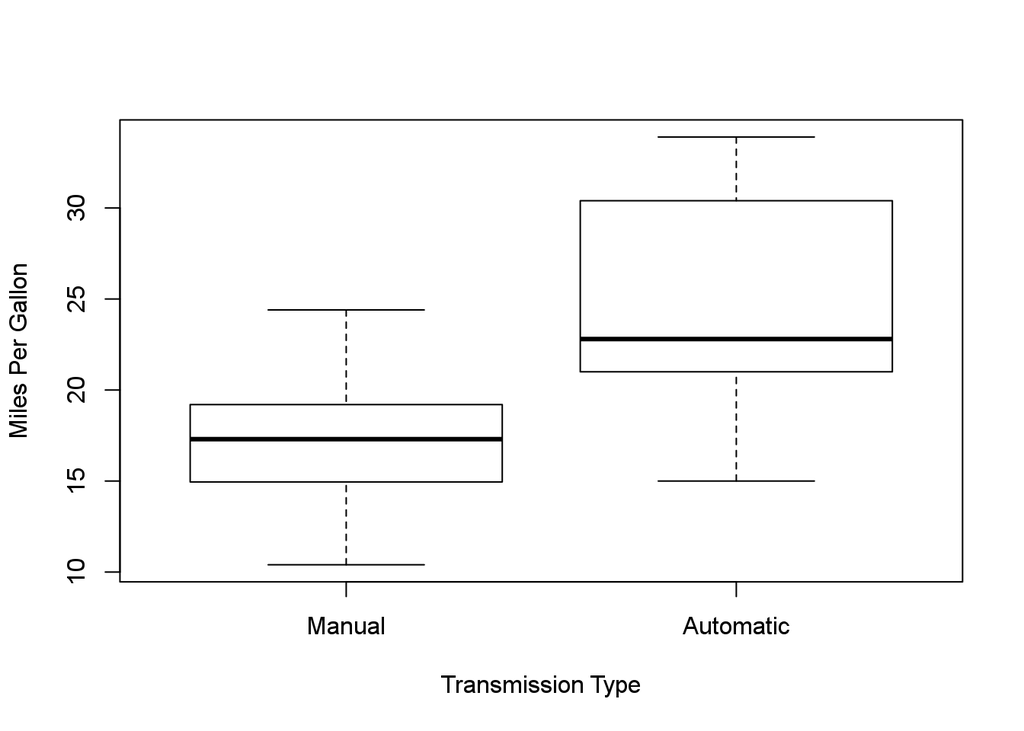

```r
boxplot(mpg[am==0],mpg[am==1], ylab ="Miles Per Gallon", xlab ="Transmission Type", names=c("Manual", "Automatic"))
```

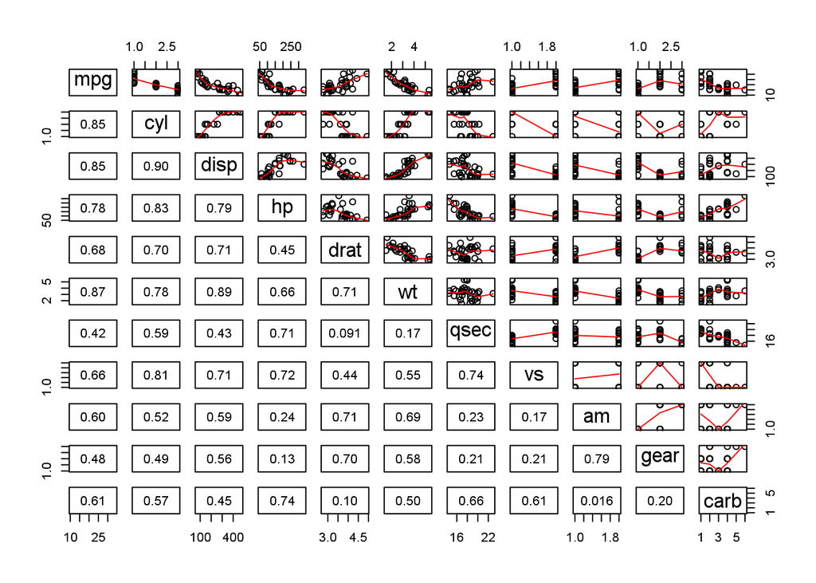

```r
pairs(mtcars, upper.panel=panel.smooth, lower.panel=panel.cor)
```

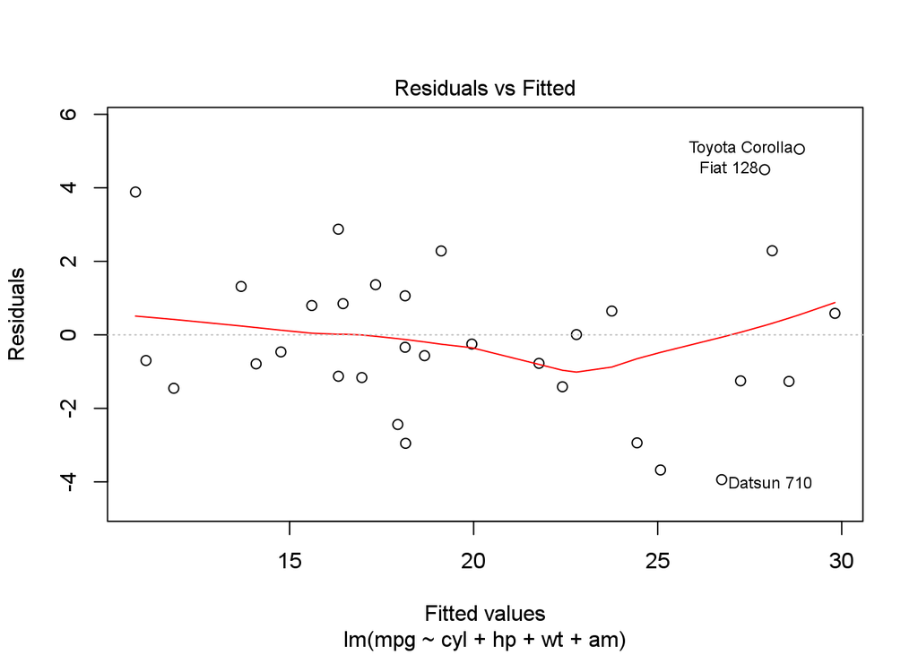

```r
plot(best.model, which=1)
```

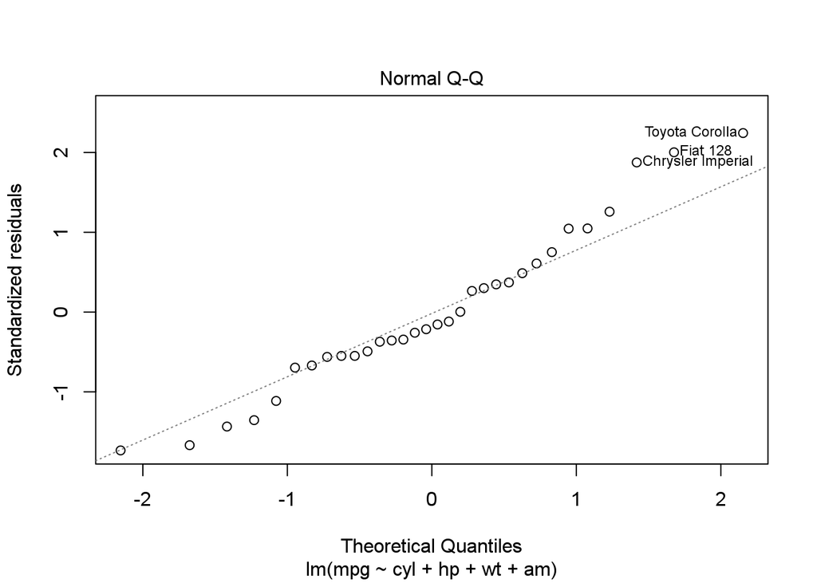

```r
plot(best.model, which=2)
```

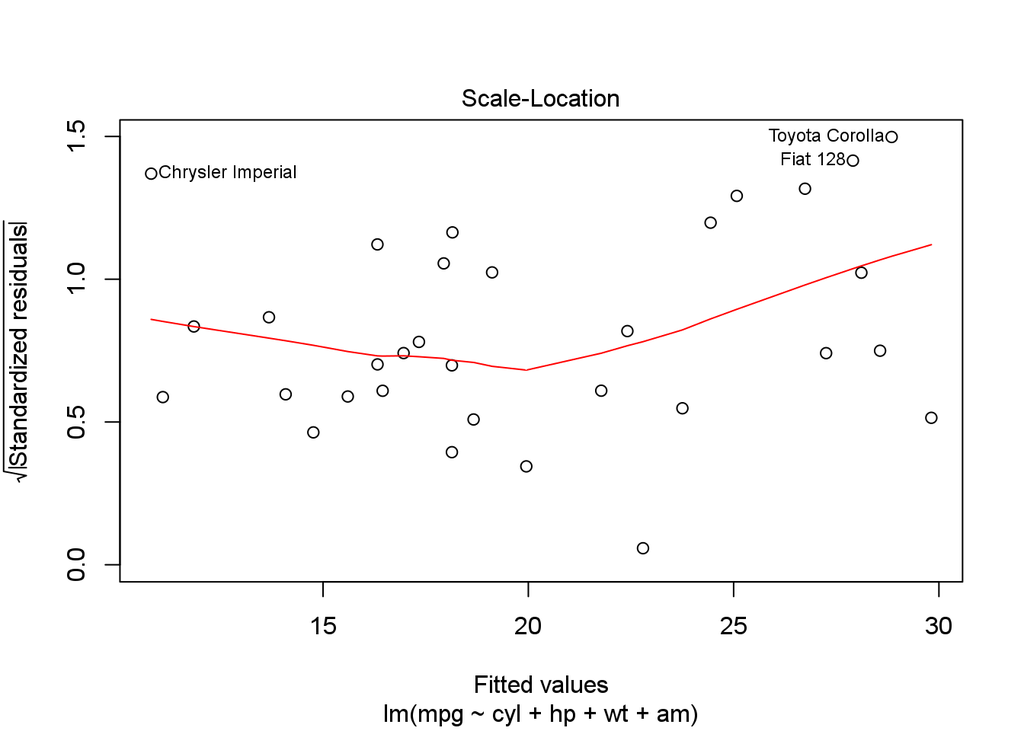

```r
plot(best.model, which=3)
```

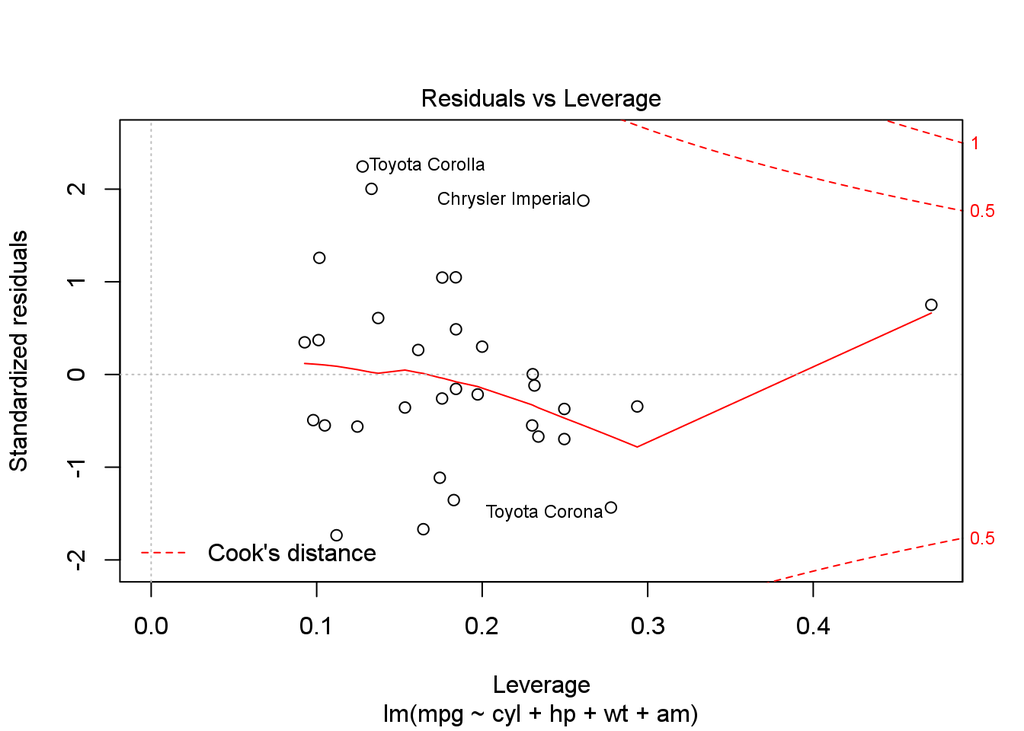

```r
plot(best.model, which=5)
```